# Ramada by Wyndham Hamilton City Center: Review Benchmarking and Price Prediction

Sheikh Mohammad Milton

17 October 2026

#1. Introduction

## 1.1 Purpose of the analysis

The purpose of this assignment is to conduct a comprehensive, data-driven analysis and develop a machine learning model to support strategic decision-making for the manager of Ramada by Wyndham Hamilton City Center.

The manager of **Ramada by Wyndham Hamilton City Center** (Tripadvisor id 3572177) wants to know:

1. What are the hotel’s **strengths and weaknesses**, and how does it compare with **competitors**?
2. What price per night would a **machine learning model** estimate for the hotel?
3. What should the hotel **do to improve**, and should the current average price of **$183.50** change?

For finding out the answers of the above question following analysis has been presented.

## 1.2 Load packages

[output not shown]

# 2. Data Import and Initial Inspection

## 2.1 Import the dataset

## 2.2 Initial Inspection

| file | rows | columns |
| --- | --- | --- |
| hotel_main | 729 | 47 |
| hotel_pred | 1 | 46 |
| hotel_review | 9585 | 19 |

```
## Rows: 729
## Columns: 47
## $ id                   <dbl> 656000, 34167717, 613082, 662163, 645374, 586425,…
## $ name                 <chr> "Accent on Taupo Motor Lodge", "Pukawa Villas", "…
## $ description          <chr> "Situated on Lake Terrace in Two Mile Bay. Our co…
## $ email                <chr> "stay@accentontaupo.com", "office@pukawavillas.co…
## $ website              <chr> NA, "https://pukawavillas.com/contact-us/", "http…
## $ phone                <chr> "+64 7-378 9919", "+64 7-386 7070", "+64 7-378 54…
## $ category             <chr> "Hotel", "Bed and Breakfast", "Hotel", "Hotel", "…
## $ address              <chr> "310 Lake Terrace Two Mile Bay, Taupo 3330 New Ze…
## $ country              <chr> "New Zealand", "New Zealand", "New Zealand", "New…
## $ locality             <chr> "Taupo", "Kuratau", "Taupo", "Taupo", "Taupo", "T…
## $ postalcode           <dbl> 3330, 3381, 3330, 3330, 3384, 3330, NA, NA, 3330,…
## $ latitude             <dbl> -38.71347, -38.92255, -38.68965, -38.69873, -38.6…
## $ longitude            <dbl> 176.0857, 175.7523, 176.0773, 176.0846, 176.0900,…
```

[output cut: 34 more lines]

```
## Rows: 9,585
## Columns: 19
## $ hotel_id           <dbl> 9981445, 9981445, 9797540, 9797540, 9797540, 979754…
## $ review_id          <dbl> 649258598, 348168278, 1001933792, 936655315, 867852…
## $ review_helpful     <dbl> 0, 0, 0, 0, 0, 0, 0, 4, 0, 0, 0, 1, 0, 0, 0, 1, 0, …
## $ user_id            <chr> "49F039CF264004B03AFA22E606C2ABE0", "1F358949DF44C9…
## $ user_location      <chr> "Hampshire, United Kingdom", "Shropshire, United Ki…
## $ user_review        <dbl> 188, 86, 173, 133, 161, 5, 218, 3, 64, 11, 1, 116, …
## $ travel_date        <chr> "2019-01", "2016-02", "2025-03", "2024-02", "2022-1…
## $ trip_type          <chr> "COUPLES", "COUPLES", "COUPLES", "COUPLES", "NONE",…
## $ review_date        <date> 2019-01-31, 2016-02-25, 2025-04-11, 2024-02-03, 20…
## $ title              <chr> "Cozy challet in the back garden of a country house…
## $ text               <chr> "Set in the back garden of a private residence is a…
## $ rating_overall     <dbl> 5, 5, 3, 5, 4, 5, 4, 3, 5, 4, 4, 4, 5, 5, 5, 5, 5, …
## $ rating_cleanliness <dbl> NA, 5, 4, NA, 5, NA, NA, NA, NA, NA, NA, 5, 5, 5, 5…
## $ rating_location    <dbl> NA, NA, 2, NA, NA, NA, 4, NA, NA, 4, NA, 5, 5, 5, 5…
## $ rating_room        <dbl> NA, NA, 3, NA, 5, NA, 3, 3, NA, 5, NA, 4, 5, 5, 5, …
## $ rating_service     <dbl> 5, 5, 3, NA, 5, NA, 5, 4, NA, 4, NA, 4, 5, 5, 5, NA…
## $ rating_sleep       <dbl> 5, NA, 5, NA, NA, NA, NA, 2, NA, NA, NA, 4, 5, 5, 5…
## $ rating_value       <dbl> NA, 5, 5, NA, NA, NA, NA, NA, NA, NA, NA, 4, 4, 5, …
## $ hotel_response     <chr> NA, NA, NA, NA, NA, NA, NA, NA, NA, NA, NA, NA, NA,…
```

```
##        id               name           description           email
##  Min.   :  255590   Length:729         Length:729         Length:729
##  1st Qu.: 1190104   Class :character   Class :character   Class :character
##  Median : 3403501   Mode  :character   Mode  :character   Mode  :character
##  Mean   : 8501352
##  3rd Qu.:13078640
##  Max.   :34522761
##
##    website             phone             category           address
##  Length:729         Length:729         Length:729         Length:729
##  Class :character   Class :character   Class :character   Class :character
##  Mode  :character   Mode  :character   Mode  :character   Mode  :character
##
##
##
##
##    country            locality           postalcode      latitude
##  Length:729         Length:729         Min.   :1004   Min.   :-43.52
##  Class :character   Class :character   1st Qu.:3330   1st Qu.:-38.26
##  Mode  :character   Mode  :character   Median :3472   Median :-37.79
##                                        Mean   :3445   Mean   :-37.76
##                                        3rd Qu.:3576   3rd Qu.:-37.11
##                                        Max.   :3998   Max.   :-36.48
##                                        NA's   :47     NA's   :3
##    longitude      hotel_class    price_class            price
##  Min.   :172.6   Min.   :0.000   Length:729         Min.   :  19.0
##  1st Qu.:175.3   1st Qu.:0.000   Class :character   1st Qu.: 145.8
##  Median :175.7   Median :0.000   Mode  :character   Median : 190.0
##  Mean   :175.6   Mean   :1.724                      Mean   : 242.4
##  3rd Qu.:175.8   3rd Qu.:3.500                      3rd Qu.: 249.8
##  Max.   :176.3   Max.   :5.000                      Max.   :4014.5
##  NA's   :3                                          NA's   :286
##       room         photo        offer_vendors    offer_pricemin
##  Min.   :  1   Min.   :   0.0   Min.   : 1.000   Min.   :  42.0
##  1st Qu.:  3   1st Qu.:   0.0   1st Qu.: 2.000   1st Qu.: 127.5
##  Median :  9   Median :  19.0   Median : 4.000   Median : 157.0
##  Mean   : 16   Mean   :  51.5   Mean   : 4.152   Mean   : 183.1
##  3rd Qu.: 17   3rd Qu.:  63.0   3rd Qu.: 6.000   3rd Qu.: 194.5
##  Max.   :322   Max.   :1112.0   Max.   :11.000   Max.   :2404.0
##  NA's   :213                    NA's   :498      NA's   :498
```

[output cut: 41 more lines]

```
##  Min.   :1.000   Min.   :1.000      Min.   :1.000   Min.   :1.000
##  1st Qu.:4.000   1st Qu.:4.300      1st Qu.:4.300   1st Qu.:4.000
##  Median :4.500   Median :4.700      Median :4.600   Median :4.450
##  Mean   :4.324   Mean   :4.481      Mean   :4.489   Mean   :4.272
##  3rd Qu.:4.900   3rd Qu.:5.000      3rd Qu.:4.900   3rd Qu.:4.900
##  Max.   :5.000   Max.   :5.000      Max.   :5.000   Max.   :5.000
##  NA's   :120     NA's   :194        NA's   :189     NA's   :195
##  rating_service   rating_sleep    rating_value
##  Min.   :1.000   Min.   :1.000   Min.   :1.0
##  1st Qu.:4.200   1st Qu.:4.100   1st Qu.:4.0
##  Median :4.600   Median :4.500   Median :4.5
##  Mean   :4.387   Mean   :4.374   Mean   :4.3
##  3rd Qu.:4.900   3rd Qu.:4.900   3rd Qu.:4.8
##  Max.   :5.000   Max.   :5.000   Max.   :5.0
##  NA's   :157     NA's   :201     NA's   :185
```

```
##        id              name           description           email
##  Min.   :3572177   Length:1           Length:1           Length:1
##  1st Qu.:3572177   Class :character   Class :character   Class :character
##  Median :3572177   Mode  :character   Mode  :character   Mode  :character
##  Mean   :3572177
##  3rd Qu.:3572177
##  Max.   :3572177
##    website             phone             category           address
##  Length:1           Length:1           Length:1           Length:1
##  Class :character   Class :character   Class :character   Class :character
##  Mode  :character   Mode  :character   Mode  :character   Mode  :character
##
##
##
##    country            locality           postalcode      latitude
##  Length:1           Length:1           Min.   :3204   Min.   :-37.79
##  Class :character   Class :character   1st Qu.:3204   1st Qu.:-37.79
##  Mode  :character   Mode  :character   Median :3204   Median :-37.79
##                                        Mean   :3204   Mean   :-37.79
##                                        3rd Qu.:3204   3rd Qu.:-37.79
##                                        Max.   :3204   Max.   :-37.79
##    longitude      hotel_class  price_class             room        photo
##  Min.   :175.3   Min.   :3.5   Length:1           Min.   :69   Min.   :233
##  1st Qu.:175.3   1st Qu.:3.5   Class :character   1st Qu.:69   1st Qu.:233
##  Median :175.3   Median :3.5   Mode  :character   Median :69   Median :233
##  Mean   :175.3   Mean   :3.5                      Mean   :69   Mean   :233
##  3rd Qu.:175.3   3rd Qu.:3.5                      3rd Qu.:69   3rd Qu.:233
##  Max.   :175.3   Max.   :3.5                      Max.   :69   Max.   :233
##  offer_vendors offer_pricemin offer_pricemax amenity_airport amenity_baggage
##  Min.   :3     Min.   :118    Min.   :146    Mode:logical    Min.   :1
##  1st Qu.:3     1st Qu.:118    1st Qu.:146    NA's:1          1st Qu.:1
##  Median :3     Median :118    Median :146                    Median :1
##  Mean   :3     Mean   :118    Mean   :146                    Mean   :1
##  3rd Qu.:3     3rd Qu.:118    3rd Qu.:146                    3rd Qu.:1
##  Max.   :3     Max.   :118    Max.   :146                    Max.   :1
##  amenity_breakfastava amenity_breakfastinc amenity_housekeep amenity_kids
##  Min.   :1            Mode:logical         Mode:logical      Mode:logical
##  1st Qu.:1            NA's:1               NA's:1            NA's:1
##  Median :1
##  Mean   :1
```

[output cut: 22 more lines]

```
##  Max.   :1                        Max.   :45    Max.   :56       Max.   :360
##  rating_overall rating_cleanliness rating_location  rating_room  rating_service
##  Min.   :3      Min.   :3.7        Min.   :4.4     Min.   :3.2   Min.   :3.6
##  1st Qu.:3      1st Qu.:3.7        1st Qu.:4.4     1st Qu.:3.2   1st Qu.:3.6
##  Median :3      Median :3.7        Median :4.4     Median :3.2   Median :3.6
##  Mean   :3      Mean   :3.7        Mean   :4.4     Mean   :3.2   Mean   :3.6
##  3rd Qu.:3      3rd Qu.:3.7        3rd Qu.:4.4     3rd Qu.:3.2   3rd Qu.:3.6
##  Max.   :3      Max.   :3.7        Max.   :4.4     Max.   :3.2   Max.   :3.6
##   rating_sleep  rating_value
##  Min.   :3.4   Min.   :3.3
##  1st Qu.:3.4   1st Qu.:3.3
##  Median :3.4   Median :3.3
##  Mean   :3.4   Mean   :3.3
##  3rd Qu.:3.4   3rd Qu.:3.3
##  Max.   :3.4   Max.   :3.3
```

| id | name | category | locality | hotel_class | price_class | price | room | review | rating_overall |
| --- | --- | --- | --- | --- | --- | --- | --- | --- | --- |
| 6.56e+05 | Accent on Taupo Motor Lodge | Hotel | Taupo | 3.5 | $ | 159 | 8 | 286 | 4.5 |
| 3.42e+07 | Pukawa Villas | Bed and Breakfast | Kuratau | 4 | $$ | 302 |  | 3 | 5 |
| 6.13e+05 | Lake Taupo Motor Inn | Hotel | Taupo | 3.5 | $$ | 178 | 32 | 398 | 4.2 |
| 6.62e+05 | Taupo Thermal Motel & Spa - Adults Only | Hotel | Taupo | 3 | $$ | 197 | 15 | 115 | 4.3 |
| 6.45e+05 | Wairakei Resort Taupo | Hotel | Taupo | 4 | $$ | 186 | 187 | 1.4e+03 | 4 |

| id | name | category | locality | hotel_class | price_class | room | review | rating_overall |
| --- | --- | --- | --- | --- | --- | --- | --- | --- |
| 3.57e+06 | Ramada by Wyndham Hamilton City Center | Hotel | Hamilton | 3.5 | $$ | 69 | 360 | 3 |

| hotel_id | review_date | trip_type | rating_overall | title |
| --- | --- | --- | --- | --- |
| 9.98e+06 | 2019-01-31 | COUPLES | 5 | Cozy challet in the back garden of a country house |
| 9.98e+06 | 2016-02-25 | COUPLES | 5 | Homely and Rural with Great Views |
| 9.8e+06 | 2025-04-11 | COUPLES | 3 | Alpacas, Alpacas, Alpacas |
| 9.8e+06 | 2024-02-03 | COUPLES | 5 | Fun place to stay |
| 9.8e+06 | 2022-11-10 | NONE | 4 | Gorgeous country location |

```
## Duplicate rows in hotel_main: 8
```

```
## Duplicate rows in hotel_review: 1
```

```
## Ramada in hotel_main?  FALSE
```

```
## Ramada in hotel_pred?  TRUE
```

```
## Ramada reviews in hotel_review: 349
```

```
## Review date range: 2005-02-20 to 2026-07-30
```

```
##      price             room         photo            review
##  Min.   :  19.0   Min.   :  1   Min.   :   0.0   Min.   :   0.0
##  1st Qu.: 145.8   1st Qu.:  3   1st Qu.:   0.0   1st Qu.:   2.0
##  Median : 190.0   Median :  9   Median :  19.0   Median :  21.0
##  Mean   : 242.4   Mean   : 16   Mean   :  51.5   Mean   : 105.7
##  3rd Qu.: 249.8   3rd Qu.: 17   3rd Qu.:  63.0   3rd Qu.: 115.0
##  Max.   :4014.5   Max.   :322   Max.   :1112.0   Max.   :2919.0
##  NA's   :286      NA's   :213
##   hotel_class    rating_overall
##  Min.   :0.000   Min.   :1.000
##  1st Qu.:0.000   1st Qu.:4.000
##  Median :0.000   Median :4.500
##  Mean   :1.724   Mean   :4.324
##  3rd Qu.:3.500   3rd Qu.:4.900
##  Max.   :5.000   Max.   :5.000
##                  NA's   :120
```

## 2.3 Initial Findings

- **Size:** `hotel_main` has 729 rows and 47 columns (one row per accommodation), `hotel_pred` has a single row (Ramada) and 46 columns, and `hotel_review` has 9,585 reviews and 19 columns.
- **Ramada is only in `hotel_pred`**, not in `hotel_main`, so the price model never sees Ramada while learning. Its 349 reviews are in `hotel_review` (Tripadvisor shows 360 reviews in total on the hotel page).
- **Duplicates:** 8 duplicated hotel rows and 1 duplicated review. They will be removed before further analysis.
- **Price is very skewed:** the median is about $190 but the mean is about $242 and the maximum is $4,014.50, so a few luxury lodges pull the average up.
- **`hotel_class` has many zeros** (more than half of the hotels). A hotel cannot have zero stars, so 0 means “not rated”, which we handle in Phase 2.
- **Amenity columns contain only 1 or `NA`**, so `NA` means “not listed”.
- Reviews run from February 2005 to July 2026, so we can study trends over time.
- Some categorical data has been treated as CHARACTER Data Type which have to be converted to CATEGORICAL Data before analysis.

# 3. Data perpetration

## 3.1 Missing value management

Missing values (`NA`) can break models and bias averages. First we measure how much is missing in each variable, then we decide purposefully what to do for each group of variables (not just delete everything).

```
## # A tibble: 39 × 2
##    variable             pct_missing
##    <chr>                      <dbl>
##  1 amenity_airport           94.2
##  2 amenity_service           91.9
##  3 amenity_breakfastava      87.8
##  4 amenity_pool              84.6
##  5 amenity_breakfastinc      83.4
##  6 amenity_housekeep         82.2
##  7 amenity_kids              75.7
##  8 amenity_wheelchair        74.5
##  9 amenity_laundryserv       74.3
## 10 amenity_baggage           74.1
## 11 amenity_laundryself       73.8
## 12 offer_vendors             68.3
```

[output cut: 27 more lines]

Missing values in hotel_main (total rows: 729 )

| Variable | Missing values (count) | Missing (%) |
| --- | --- | --- |
| amenity_airport | 687 | 94.2 |
| amenity_service | 670 | 91.9 |
| amenity_breakfastava | 640 | 87.8 |
| amenity_pool | 617 | 84.6 |
| amenity_breakfastinc | 608 | 83.4 |
| amenity_housekeep | 599 | 82.2 |
| amenity_kids | 552 | 75.7 |
| amenity_wheelchair | 543 | 74.5 |
| amenity_laundryserv | 542 | 74.3 |
| amenity_baggage | 540 | 74.1 |
| amenity_laundryself | 538 | 73.8 |
| offer_vendors | 498 | 68.3 |
| offer_pricemin | 498 | 68.3 |
| offer_pricemax | 498 | 68.3 |
| amenity_kitchen | 419 | 57.5 |
| amenity_nonsmoke | 358 | 49.1 |
| amenity_wifi | 348 | 47.7 |
| description | 298 | 40.9 |
| price_class | 286 | 39.2 |
| price | 286 | 39.2 |
| amenity_parking | 264 | 36.2 |
| website | 240 | 32.9 |
| email | 226 | 31.0 |
| room | 213 | 29.2 |
| rating_sleep | 201 | 27.6 |
| rating_room | 195 | 26.7 |
| rating_cleanliness | 194 | 26.6 |
| rating_location | 189 | 25.9 |
| rating_value | 185 | 25.4 |
| rating_service | 157 | 21.5 |
| phone | 126 | 17.3 |
| rank_string | 120 | 16.5 |
| rank_position | 120 | 16.5 |
| rank_denominator | 120 | 16.5 |
| rating_overall | 120 | 16.5 |
| postalcode | 47 | 6.4 |
| locality | 6 | 0.8 |
| latitude | 3 | 0.4 |
| longitude | 3 | 0.4 |

**Findings:**

| variable | pct_missing |
| --- | --- |
| rating_sleep | 58.6 |
| rating_room | 57.3 |
| rating_cleanliness | 56.3 |
| rating_location | 55.5 |
| rating_value | 54.5 |
| hotel_response | 48.6 |
| rating_service | 33.8 |
| user_location | 33 |
| user_id | 0.0209 |
| user_review | 0.0209 |
| travel_date | 0.0209 |
| trip_type | 0.0209 |
| title | 0.0209 |

## 3.2 Removing duplicates

```
##  [1] "Taupo"      "Hamilton"   "Whitianga"  "Cambridge"  "Coromandel"
##  [6] "Thames"     "Turangi"    "Raglan"     "Waihi"      "Whangamata"
```

## 3.3 Creating new variables

New variables simplify the information (for example “Economy / Moderate / Premium / Luxury” is easier to compare than “$", "$$” and so on), and some capture ideas such as how many amenities a hotel offers. We write one small function so that exactly the same steps are applied to `hotel_main` and to Ramada’s row in `hotel_pred`.

| name | price_class | price_cat | hotel_class | star_cat | room | room_size | amenity_count | area |
| --- | --- | --- | --- | --- | --- | --- | --- | --- |
| Accent on Taupo Motor Lodge | $ | Economy | 3.5 | 3-3.5 Stars | 8 | Small (1-10) | 6 | Taupo |
| Pukawa Villas | $$ | Moderate | 4 | 4-5 Stars |  | Unknown | 0 | Other |
| Lake Taupo Motor Inn | $$ | Moderate | 3.5 | 3-3.5 Stars | 32 | Large (31+) | 9 | Taupo |
| Taupo Thermal Motel & Spa - Adults Only | $$ | Moderate | 3 | 3-3.5 Stars | 15 | Medium (11-30) | 4 | Taupo |
| Wairakei Resort Taupo | $$ | Moderate | 4 | 4-5 Stars | 187 | Large (31+) | 10 | Taupo |
| Taupo DeBretts Spa Resort | $$ | Moderate | 4.5 | 4-5 Stars | 36 | Large (31+) | 9 | Taupo |
| Turangi Bridge Motel | $ | Economy | 3 | 3-3.5 Stars | 31 | Large (31+) | 6 | Turangi |
| Suncourt | $$ | Moderate | 4 | 4-5 Stars | 52 | Large (31+) | 12 | Taupo |
| Beechtree Motel | $ | Economy | 4 | 4-5 Stars | 39 | Large (31+) | 9 | Taupo |
| Lake Taupo Holiday Resort | $$$ | Premium | 5 | 4-5 Stars | 43 | Large (31+) | 8 | Taupo |

| group | n |
| --- | --- |
| Hamilton competitors | 7583 |
| Other areas | 1652 |
| Ramada | 349 |

## 3.4 Defining Competitors

Ramada’s competitors are the other hotels located in Hamilton. We use the same competitors for both the hotel-level and review-level comparisons.

```
## Hamilton competitor hotels: 102
```

```
## Competitor hotels with reviews: 76
```

# 4. Exploratory Data Analysis (EDA)

## 4.1 Understanding Price

Price is what we will predict through Machine Learning, so we must understand its typical level, how spread out it is, and whether there are extreme values.

| n | mean | median | sd | min | max |
| --- | --- | --- | --- | --- | --- |
| 435 | 243 | 189 | 283 | 19 | 4.01e+03 |

| category | n | mean | median | sd | min | max |
| --- | --- | --- | --- | --- | --- | --- |
| Bed and Breakfast | 150 | 236 | 180 | 166 | 65 | 1.06e+03 |
| Hotel | 151 | 193 | 178 | 94 | 61 | 1.03e+03 |
| Specialty Lodging | 134 | 309 | 206 | 461 | 19 | 4.01e+03 |

| price_cat | n | mean | median |
| --- | --- | --- | --- |
| Economy | 181 | 133 | 139 |
| Moderate | 203 | 228 | 220 |
| Premium | 29 | 384 | 378 |
| Luxury | 22 | 1.11e+03 | 884 |

| star_cat | n | mean | median |
| --- | --- | --- | --- |
| 1-2.5 Stars | 20 | 224 | 113 |
| 3-3.5 Stars | 135 | 182 | 175 |
| 4-5 Stars | 133 | 343 | 230 |
| Unrated | 147 | 212 | 180 |

```
## Upper fence: 403
```

```
## Hotels above the fence: 33
```

```
## Hotels above $1000: 9
```

| name | locality | category | price | room |
| --- | --- | --- | --- | --- |
| Kinloch Manor & Villas | Kinloch | Specialty Lodging | 4.01e+03 | 18 |
| The Point Villas | Taupo | Specialty Lodging | 2.53e+03 | 6 |
| Omori Lodge | Omori | Specialty Lodging | 2.07e+03 | 11 |
| Waitomo Boutique Lodge | Te Kuiti | Specialty Lodging | 1.7e+03 | 3 |
| Lake Vista Lodge | Taupo | Bed and Breakfast | 1.06e+03 |  |
| Acacia Bay | Taupo | Bed and Breakfast | 1.06e+03 |  |
| Lake Taupo Lodge | Taupo | Specialty Lodging | 1.05e+03 | 6 |
| Peninsula Waterfront Retreat | Whangamata | Specialty Lodging | 1.04e+03 | 3 |
| River Birches Lodge | Turangi | Hotel | 1.03e+03 | 4 |
| MERCURY RIDGE | Cooks Beach | Bed and Breakfast | 994 | 5 |

## 4.2 Ramada’s current price versus Hamilton hotels

| hotels | mean | median | q25 | q75 |
| --- | --- | --- | --- | --- |
| 67 | 173 | 148 | 130 | 204 |

```
## Share of Hamilton competitors priced at or below $183.50: 63 %
```

| category | hotels | median |
| --- | --- | --- |
| Bed and Breakfast | 19 | 148 |
| Hotel | 37 | 163 |
| Specialty Lodging | 11 | 132 |

Findings:

- Price is strongly right-skewed: the mean (about $243) is well above the median (about $189), and the standard deviation (about $283) is larger than the mean. Extreme lodges (for example $4,014 and $2,528) pull the average up, so the median is a better “typical” price.
- By type: Hotels have the narrowest spread (standard deviation about $94). Specialty Lodging has the highest mean ($309) but a much lower median ($206), which shows a few very expensive properties. Bed and Breakfasts are in between.
- By price category: the median rises clearly from Economy ($139) to Moderate ($220), Premium ($378) and Luxury ($884).
- By stars: 4-5 star hotels have a median of about $230 compared with about $175 for 3-3.5 star hotels, so star class matters for price.
- Outliers: 33 hotels are above the IQR upper fence of about $403 and 9 are above $1,000. These are luxury lodges, very different from a city hotel such as Ramada, so we exclude hotels above $1,000 when training the model.
- Ramada’s position: its current price of $183.50 is close to the overall median, but in Hamilton it is above most competitors. The median Hamilton price is about $148 and Ramada is priced higher than roughly 63% of Hamilton hotels. Only the Hamilton hotels classified as “Moderate” by Tripadvisor have a higher median (about $208), so Ramada is already priced in the upper-middle of its local market.

## 4.3 Graphs and interpretation

### Graph 1: How is price distributed?

A histogram shows the shape of the price data. Right-skewed data (a long tail of expensive hotels) is usually easier to model after a log transformation.

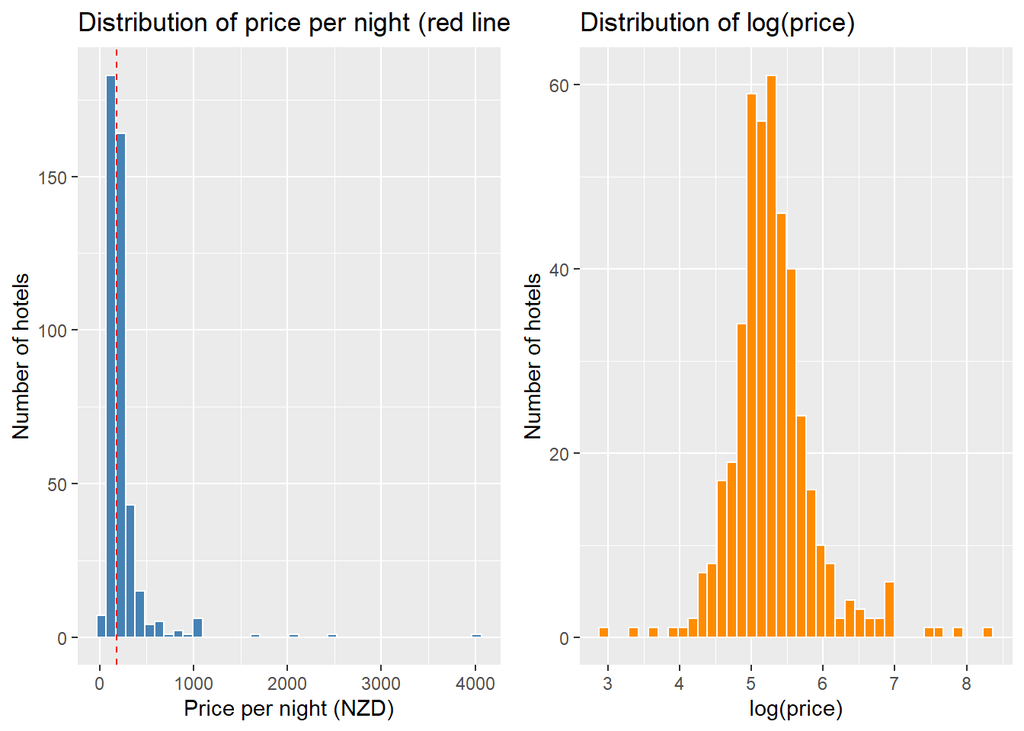

**Interpretation:**

- The first histogram shows a long right tail: most hotels charge less than about $400, but a handful charge far more. Skewness (a measure of lopsidedness) is about 8.0 for price.
- The red dashed line shows Ramada’s $183.50, which is near the middle of the distribution.
- After taking the log, the shape is much more balanced (skewness falls to about 1.0).

### Graph 2: Price by type of accommodation and by price category

Boxplots compare the middle and spread of price across groups. We use a log axis because of the long tail.

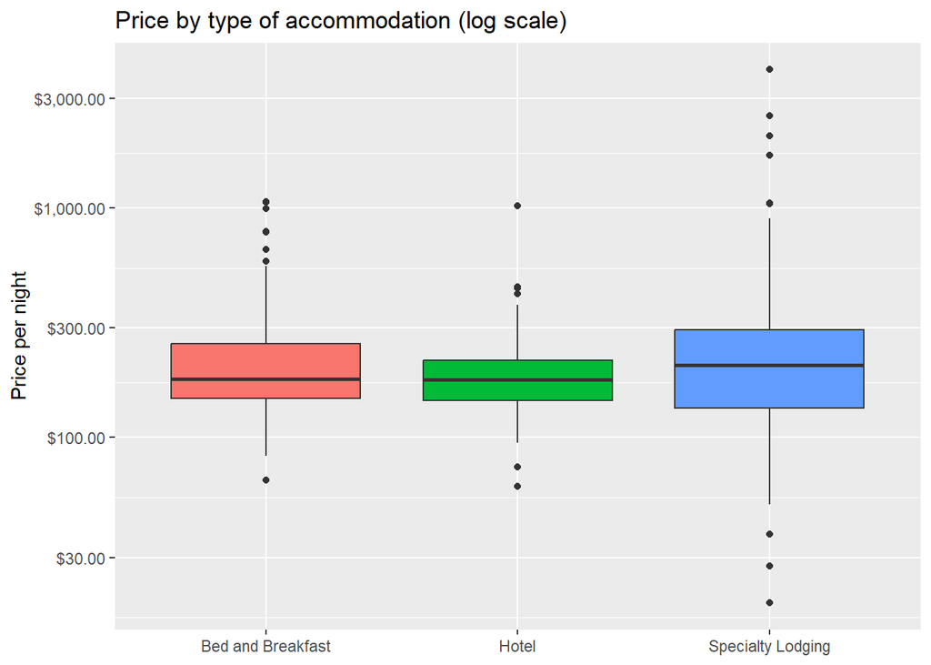

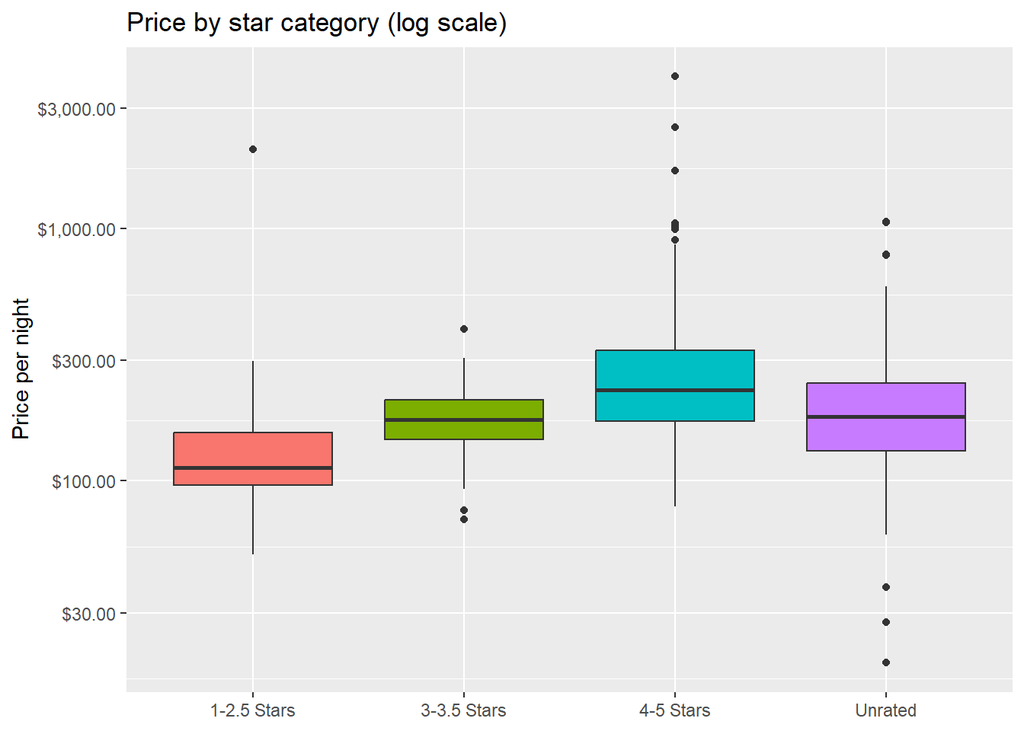

**Interpretation:**

- By type: the medians for Hotels, Bed and Breakfasts and Specialty Lodging are fairly close (about $178 to $206). Specialty Lodging has the widest spread and the most extreme points, so type alone does not set the price level.
- By stars: price rises with star class. 4-5 star properties have the highest median, 1-2.5 stars the lowest (about $113). The “Unrated” group is a mixture of all kinds of properties and has a wide spread.
- Conclusion: star class is a more useful price signal than accommodation type.

### Graph 3: Does a better rating mean a higher price?

A scatter plot shows the relationship between two numeric variables. If guests rate a hotel higher, can it charge more?

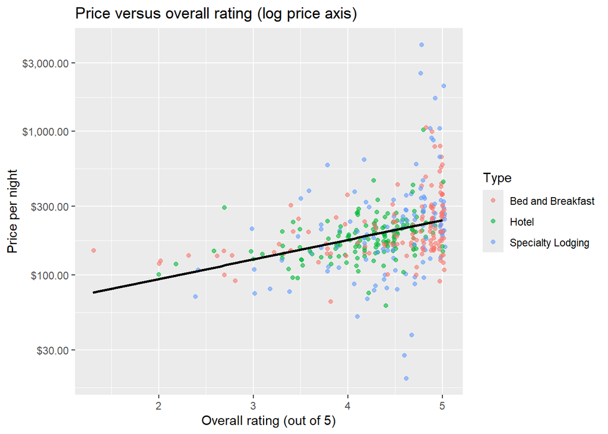

**Interpretation:**

- The black line slopes upwards: hotels with higher guest ratings tend to charge more.
- However, the points are widely scattered. Hotels with the same rating can have very different prices, so rating explains only part of the price. Other factors such as location, size, season and facilities also matter.
- Ramada’s overall rating (3.0) is at the low end of the range. If guests rate a hotel lower, the market supports a lower price, which is relevant to the manager’s plan to raise the price.

### Graph 4: Correlation heatmap

Correlation measures how strongly two numeric variables move together (from -1 to +1). The heatmap shows which variables are related to price and which are related to each other.

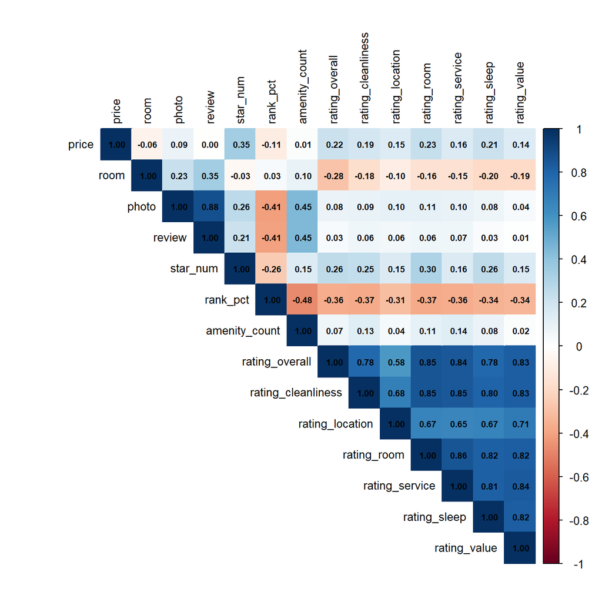

**Interpretation:**

- Relationships with price are modest. The strongest correlations with price are star class (about 0.35), the room rating (0.23), the overall rating (0.22) and the sleep rating (0.21). Number of reviews (0.00), number of amenities (0.01) and number of rooms (-0.06) show almost no linear relationship with price. (Extreme prices weaken these correlations, which is another reason to treat the biggest outliers carefully.)
- The rating variables are strongly correlated with one another (about 0.78 to 0.86, with location lower at 0.58 to 0.71), and the number of photos and number of reviews are almost the same signal (0.88). They carry overlapping information, so a simple linear model may struggle with them (multi-collinearity). Regularized models (lasso/ridge) and tree-based models cope better

### Graph 5: Where are the expensive hotels?

Location is a classic price driver. We look at average price by area and at a simple map of hotels coloured by price.

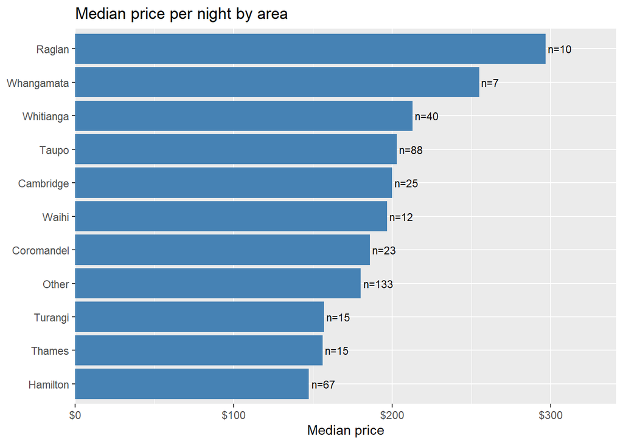

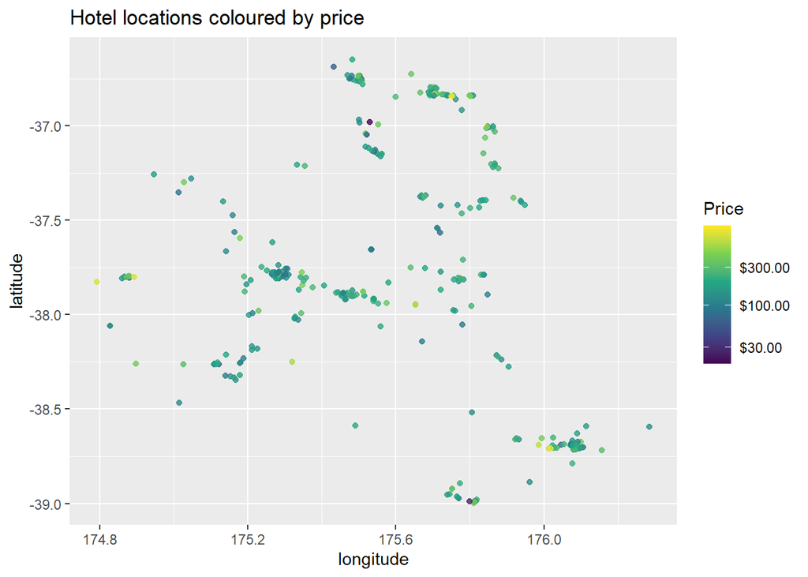

**Interpretation:**

- Hamilton, Ramada’s own market, has the lowest median price (about $148, 67 hotels), because it is a large city with many motels and business hotels. Tourist destinations are more expensive: Raglan (about $297, but only 10 hotels), Whitianga (about $213), Taupo (about $203) and Cambridge (about $200).
- The map shows that hotels cluster around towns, and the colour pattern confirms that location is related to price. This is why `area`, latitude and longitude are included in the model.
- Ramada’s $183.50 is therefore a relatively high price for Hamilton.

### Graph 6: Ramada versus Hamilton competitors on each aspect

This is the key benchmarking graph. Bars side by side show where Ramada is above or below the Hamilton average.

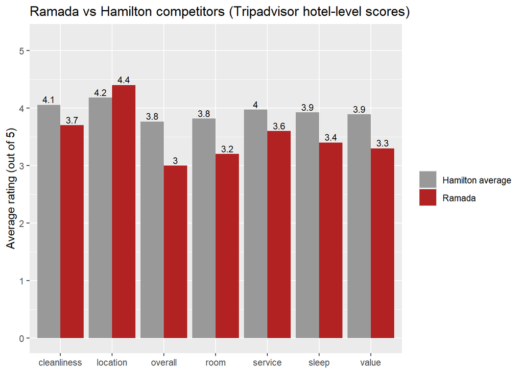

**Interpretation:**

- Ramada (red) is **lower than the Hamilton average (grey) on every aspect except location**.
- The biggest gaps are overall rating, room, value and sleep. These are the aspects that guests link most closely to the quality of the physical product and the price paid.
- Location (4.4) is Ramada’s strongest score and the main competitive advantage.

### Graph 7: Distribution of star ratings in reviews

**Why are we doing this?** An average can hide the detail. Looking at the *share* of 1 to 5 star reviews shows whether guests are polarised or consistently happy.

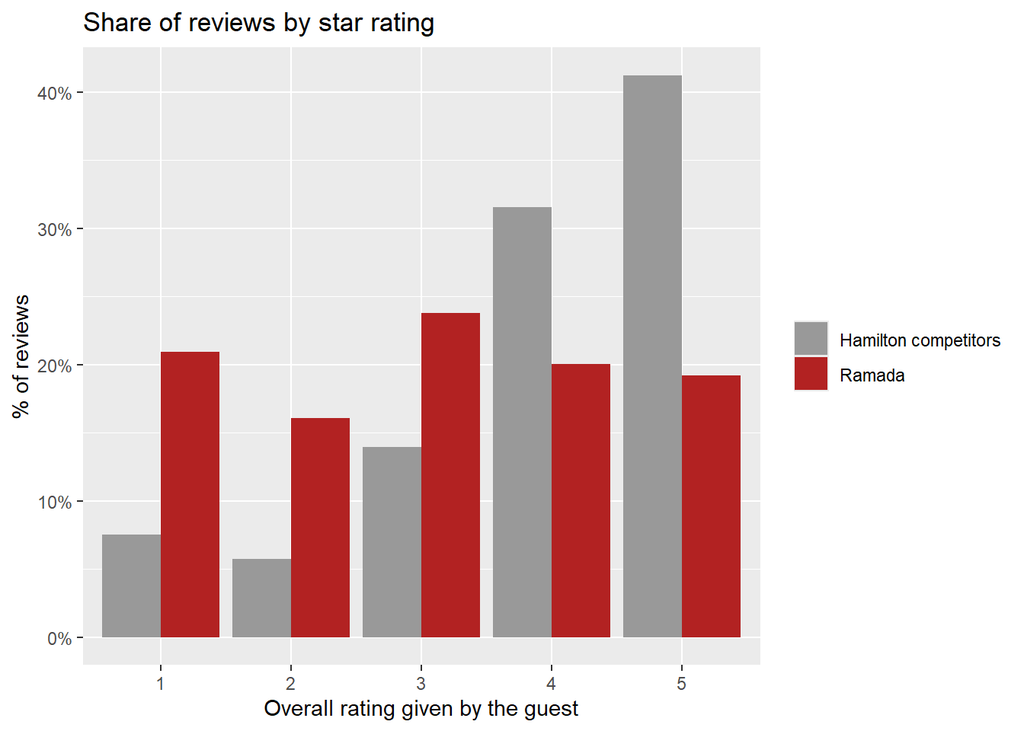

**Interpretation:**

- Ramada’s review ratings are polarised and skewed to the low end: about 37% of its reviews are 1 or 2 stars (21% give 1 star), compared with about 13% for competitors. Only about 39% of Ramada reviews are 4 or 5 stars, compared with about 73% for competitors.
- Five-star reviews make up 19% of Ramada’s reviews but 41% of competitors’ reviews.
- This means the low average is not caused by a few angry guests. A large share of guests have a poor experience.

### Graph 8: Has Ramada’s rating changed over time?

A trend line shows whether the hotel is improving or getting worse. Years with fewer than 5 reviews are dropped because the average would be unreliable.

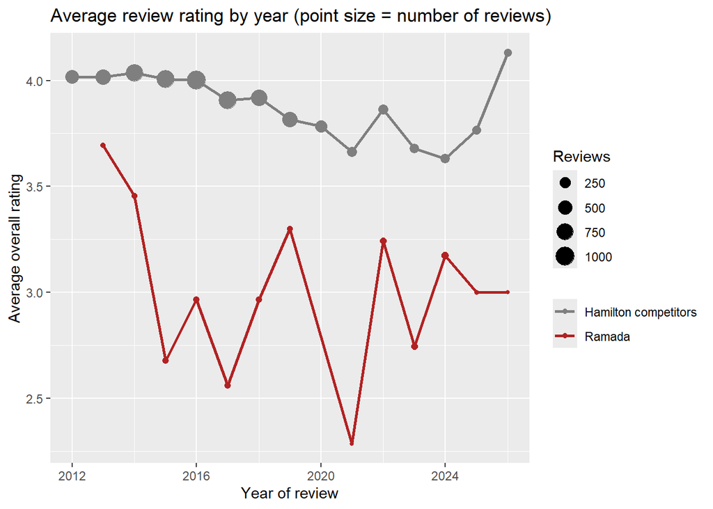

**Interpretation:**

- Ramada is below the competitor average in every year with enough reviews (2013 to 2025). Competitors stay around 3.6 to 4.0, while Ramada ranges from about 2.3 to 3.7.
- There is no clear sustained improvement: for example Ramada averaged about 3.3 in 2019, 3.2 in 2022, 2.7 in 2023 and 3.2 in 2024. The gap narrowed in some years but never closed.
- Be careful with 2025 and 2026: there are only 10 and 8 Ramada reviews, so those averages are unreliable. There are too few Ramada reviews in 2020 to plot, which fits the COVID period.

### Graph 9: Ramada ratings by type of traveler

Different guests want different things (business travellers vs families). Knowing which segment is least satisfied helps target improvements.

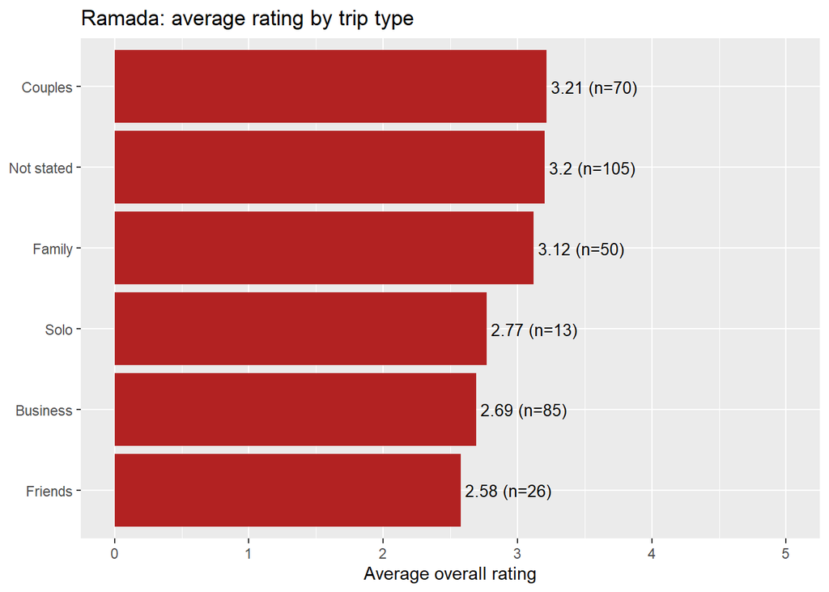

**Interpretation:**

- Business travellers (average about 2.69, 85 reviews), friends (2.58, 26 reviews) and solo travellers (2.77, 13 reviews) give the lowest ratings. Couples (3.21) and families (3.12) are somewhat happier.
- Business guests are the largest identifiable group of reviewers and one of the least satisfied, which matters because they are probably a core market for a city-centre hotel.
- The friends and solo groups are small, so treat those two bars with caution.

### Graph 10: Does the hotel respond to reviews?

Replying to guests (especially unhappy ones) shows that the hotel cares and can protect its reputation. We compare response rates by rating.

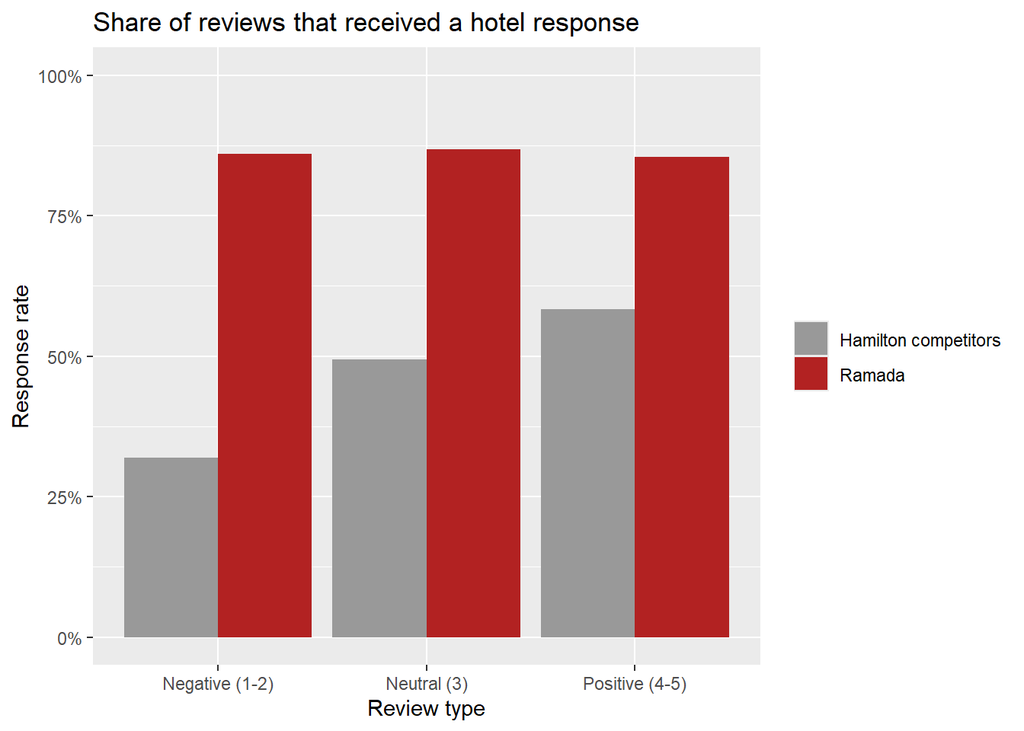

**Interpretation:**

- Ramada replies to 85% to 87% of reviews whatever the rating. Competitors reply to only about 32% of negative reviews, 49% of neutral reviews and 58% of positive reviews.
- Ramada’s responsiveness is a real strength: it shows guests that the management is listening. However, replying does not by itself fix the underlying problems that cause the low ratings.

## 4.4 Statistical tests

A graph can suggest a difference, but a statistical test tells us whether the difference is real or could just be chance. We use a significance level of 5%: if the p-value is below 0.05 we say the result is statistically significant. Because price and ratings are skewed or ordinal, we mainly use non-parametric tests (Kruskal-Wallis, Wilcoxon, Spearman) that do not assume a normal distribution.

### Test 1: Does price differ across types of accommodation? (Kruskal-Wallis)

- H0: median price is the same for Hotels, Bed and Breakfasts (B&Bs) and Specialty Lodging.
- H1: at least one type has a different price.

```
##
##  Kruskal-Wallis rank sum test
##
## data:  price by category
## Kruskal-Wallis chi-squared = 6.4692, df = 2, p-value = 0.03938
```

```
##
##  Pairwise comparisons using Wilcoxon rank sum test with continuity correction
##
## data:  price_data$price and price_data$category
##
##                   Bed and Breakfast Hotel
## Hotel             0.280             -
## Specialty Lodging 1.000             0.036
##
## P value adjustment method: bonferroni
```

**Interpretation:**

- The Kruskal-Wallis p-value is 0.039, which is below 0.05, so we reject H0: price is not the same across all types of accommodation.
- The pairwise tests show that the only significant difference is Hotel vs Specialty Lodging (adjusted p = 0.036). Bed and Breakfasts are not significantly different from the others.
- The evidence is moderate: the type of accommodation matters a little, but much less than star class.

### Test 2: Which variables are related to price? (Spearman correlation)

- H0: there is no monotonic relationship between price and the variable (correlation = 0).

| variable | n | rho | p_value |
| --- | --- | --- | --- |
| rating_overall | 398 | 0.425 | 7.09e-19 |
| rating_value | 381 | 0.328 | 5.29e-11 |
| rating_room | 381 | 0.503 | 7.72e-26 |
| room | 376 | -0.196 | 0.000126 |
| photo | 435 | 0.156 | 0.00113 |
| review | 435 | 0.05 | 0.298 |
| amenity_count | 435 | 0.099 | 0.0394 |
| star_num | 288 | 0.499 | 1.65e-19 |

**Interpretation:**

- The strongest positive relationships with price are star class (rho about 0.50), the room rating (about 0.50), the overall rating (about 0.43) and the value rating (about 0.33). All have p-values far below 0.05.
- The number of rooms has a significant negative relationship (rho about -0.20): larger properties tend to charge less per night.
- Photos (0.16) and number of amenities (0.10) are statistically significant but very weak. The number of reviews is not significant (p = 0.30), which means popularity does not translate into price.
- Quality indicators (stars and room quality) are what the market pays for. This is important for Ramada, whose room rating (3.2) is low.

### Test 3: Is the type of accommodation linked to its price level? (Chi-square)

- H0: type of accommodation and price level are independent.

```
##
##                     Economy Moderate Premium/Luxury
##   Bed and Breakfast      64       67             19
##   Hotel                  67       78              6
##   Specialty Lodging      50       58             26
```

```
##
##  Pearson's Chi-squared test
##
## data:  chi_table
## X-squared = 16.764, df = 4, p-value = 0.002148
```

**Interpretation:**

- The chi-square p-value is 0.002 (below 0.05), so we reject independence: the type of accommodation is linked to its price level.
- Specialty Lodging is much more likely to be Premium/Luxury (26 of 134 properties, about 19%) than Hotels (6 of 151, about 4%). Hotels are mostly Economy or Moderate.
- This fits the earlier boxplots: very expensive properties are mostly specialty lodges, not hotels like Ramada.

### Test 4: Is Ramada’s rating different from competitors? (Wilcoxon rank-sum)

- H0: Ramada and Hamilton competitors have the same rating distribution.
- We run the test for 7 ratings, so we use the Bonferroni rule: significant only if p < 0.05 / 7 = 0.007. This avoids false alarms from running many tests.

| rating | Ramada_mean | Comp_mean | p_value | difference | verdict |
| --- | --- | --- | --- | --- | --- |
| rating_overall | 3.01 | 3.93 | 3.08e-36 | -0.92 | Ramada significantly LOWER |
| rating_cleanliness | 3.67 | 4.26 | 1.03e-10 | -0.59 | Ramada significantly LOWER |
| rating_location | 4.39 | 4.39 | 0.785 | 0 | No significant difference |
| rating_room | 3.19 | 4 | 2.65e-14 | -0.81 | Ramada significantly LOWER |
| rating_service | 3.59 | 4.17 | 1.13e-12 | -0.58 | Ramada significantly LOWER |
| rating_sleep | 3.42 | 4.1 | 5.32e-11 | -0.68 | Ramada significantly LOWER |
| rating_value | 3.25 | 4.06 | 2.22e-15 | -0.81 | Ramada significantly LOWER |

**Interpretation:**

- Using the stricter Bonferroni threshold (0.007), Ramada is significantly lower than competitors on six of the seven ratings, with p-values far below 0.001.
- The gaps are largest for the overall rating (-0.92), room (-0.81) and value (-0.81), then sleep (-0.68), cleanliness (-0.59) and service (-0.58).

Location is the only rating with no significant difference (4.39 for both, p = 0.79).

- So Ramada’s weaknesses are real and not due to chance, and location is its one area of parity with competitors.

### Test 5: Do traveller types rate Ramada differently? (Kruskal-Wallis)

```
##
##  Kruskal-Wallis rank sum test
##
## data:  rating_overall by trip_type
## Kruskal-Wallis chi-squared = 10.979, df = 5, p-value = 0.0518
```

### Test 6: Has Ramada improved since the COVID period? (Wilcoxon)

- Compare reviews posted up to 2019 with reviews posted from 2022 onward.

| period | n | mean_rating |
| --- | --- | --- |
| 2022 onward | 158 | 3.04 |
| Up to 2019 | 181 | 2.99 |

```
##
##  Wilcoxon rank sum test with continuity correction
##
## data:  rating_overall by period
## W = 14658, p-value = 0.6841
## alternative hypothesis: true location shift is not equal to 0
```

**Interpretation of Tests 5 and 6:**

- Test 5: p = 0.052, just above 0.05, so the differences between traveller types are suggestive but not statistically significant. Business travellers look less satisfied, but we cannot be certain.
- Test 6: the average rating was 2.99 up to 2019 and 3.04 from 2022 onward, with p = 0.68. There is no significant improvement since the COVID period, so the problems have not been solved over time.

### Tests 7 to 10: Parametric tests (t-test, ANOVA, Pearson correlation)

So far we used non-parametric tests, which compare ranks. Parametric tests compare means and are more powerful when their assumptions are reasonable. Their main assumption is roughly normal data, or a large sample size (the Central Limit Theorem makes means behave normally when samples are large). Here we use them where this holds:

- review ratings, where we have hundreds of reviews per group, and
- log(price), which is much more symmetric than price (see Graph 1).

When we compare means of `log(price)`, a difference can be turned into a percentage: `exp(difference) - 1`.

#### Test 7: Do Ramada and competitors have different average review ratings? (Welch t-test)

- H0: the mean overall rating is the same for Ramada and Hamilton competitors.
- H1: the means are different.

```
##
##  Welch Two Sample t-test
##
## data:  rating_overall by group
## t = 12.118, df = 372.03, p-value < 2.2e-16
## alternative hypothesis: true difference in means between group Hamilton competitors and group Ramada is not equal to 0
## 95 percent confidence interval:
##  0.7758201 1.0763609
## sample estimates:
## mean in group Hamilton competitors               mean in group Ramada
##                           3.931821                           3.005731
```

#### Test 8: Are Hamilton hotels cheaper than hotels in other areas? (Welch t-test on log price)

- H0: mean log(price) is the same in Hamilton and elsewhere.

```
##
##  Welch Two Sample t-test
##
## data:  log(price) by market
## t = -4.3051, df = 134.78, p-value = 3.188e-05
## alternative hypothesis: true difference in means between group Hamilton and group Other areas is not equal to 0
## 95 percent confidence interval:
##  -0.3432654 -0.1271585
## sample estimates:
##    mean in group Hamilton mean in group Other areas
##                  5.082239                  5.317451
```

| market | hotels | typical_price |
| --- | --- | --- |
| Hamilton | 67 | 161 |
| Other areas | 368 | 204 |

#### Test 9: Does price differ by star category? (One-way ANOVA and Tukey test)

- H0: mean log(price) is the same for all star categories.
- If ANOVA is significant, Tukey’s HSD shows which pairs differ.

```
##              Df Sum Sq Mean Sq F value   Pr(>F)
## star_cat      3  16.82   5.607   19.89 4.33e-12 ***
## Residuals   431 121.53   0.282
## ---
## Signif. codes:  0 '***' 0.001 '**' 0.01 '*' 0.05 '.' 0.1 ' ' 1
```

```
##   Tukey multiple comparisons of means
##     95% family-wise confidence level
##
## Fit: aov(formula = log(price) ~ star_cat, data = price_data)
##
## $star_cat
##                                diff         lwr        upr     p adj
## 3-3.5 Stars-1-2.5 Stars  0.25835188 -0.06978921  0.5864930 0.1783655
## 4-5 Stars-1-2.5 Stars    0.66371804  0.33525874  0.9921773 0.0000017
## Unrated-1-2.5 Stars      0.28849595 -0.03791238  0.6149043 0.1044151
## 4-5 Stars-3-3.5 Stars    0.40536615  0.23804481  0.5726875 0.0000000
## Unrated-3-3.5 Stars      0.03014407 -0.13311438  0.1934025 0.9643060
## Unrated-4-5 Stars       -0.37522209 -0.53911916 -0.2113250 0.0000000
```

| star_cat | hotels | typical_price |
| --- | --- | --- |
| 1-2.5 Stars | 20 | 134 |
| 3-3.5 Stars | 135 | 174 |
| 4-5 Stars | 133 | 261 |
| Unrated | 147 | 179 |

```
##
##  Kruskal-Wallis rank sum test
##
## data:  log(price) by star_cat
## Kruskal-Wallis chi-squared = 55.61, df = 3, p-value = 5.088e-12
```

#### Test 10: Are ratings linearly related to price? (Pearson correlation)

- H0: the Pearson correlation between log(price) and the variable is 0.
- We use log(price) because Pearson correlation is sensitive to extreme values.

| variable | n | r | ci_low | ci_high | p_value |
| --- | --- | --- | --- | --- | --- |
| rating_overall | 398 | 0.351 | 0.261 | 0.434 | 5.8e-13 |
| rating_room | 381 | 0.385 | 0.296 | 0.467 | 6.52e-15 |
| rating_value | 381 | 0.238 | 0.141 | 0.33 | 2.65e-06 |
| star_num | 288 | 0.542 | 0.455 | 0.619 | 2.31e-23 |

## 4.5 Dimensionality reduction: Principal Component Analysis (PCA) of the ratings

We have six rating scores for each hotel (cleanliness, location, room, service, sleep, value), and the correlation heatmap showed they overlap a lot. PCA combines correlated variables into a few new variables called principal components (PCs) that capture most of the information. PC1 captures the largest possible share of the variation, PC2 the next largest, and so on. We standardize the ratings first (`scale. = TRUE`) so that each counts equally. Ramada is included because it is in `hotel_pred`.

```
## Hotels used for PCA: 486
```

```
## Importance of components:
##                           PC1     PC2     PC3     PC4     PC5     PC6
## Standard deviation     2.2269 0.63845 0.44571 0.41819 0.37422 0.34631
## Proportion of Variance 0.8265 0.06794 0.03311 0.02915 0.02334 0.01999
## Cumulative Proportion  0.8265 0.89441 0.92752 0.95667 0.98001 1.00000
```

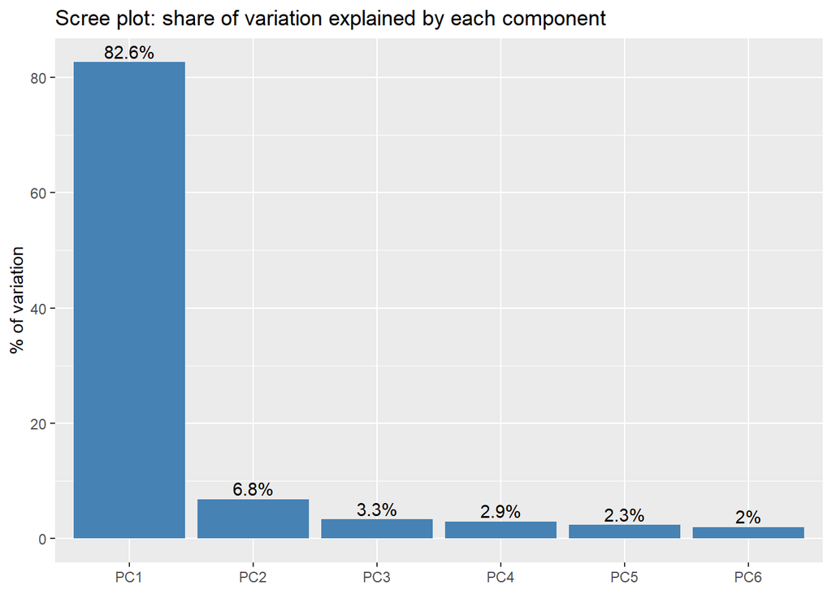

| rating | PC1 | PC2 |
| --- | --- | --- |
| rating_cleanliness | 0.42 | -0.14 |
| rating_location | 0.36 | 0.91 |
| rating_room | 0.42 | -0.25 |
| rating_service | 0.42 | -0.28 |
| rating_sleep | 0.41 | -0.08 |
| rating_value | 0.42 | -0.05 |

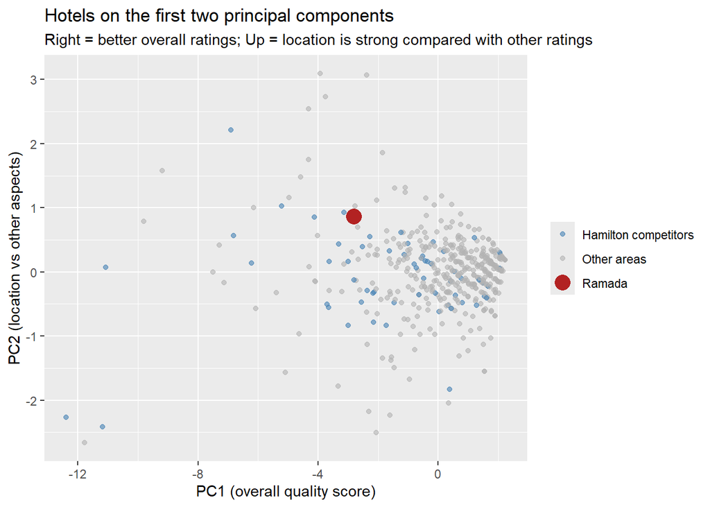

```
## Ramada PC1: -2.79 | Hamilton competitors average PC1: -1.41
```

```
## Share of Hamilton competitors with a BETTER PC1 score than Ramada: 75 %
```

```
## Ramada PC2: 0.87 | Hamilton competitors average PC2: -0.08
```

```
##
##  Pearson's product-moment correlation
##
## data:  pca_price$PC1 and log(pca_price$price)
## t = 6.8242, df = 367, p-value = 3.667e-11
## alternative hypothesis: true correlation is not equal to 0
## 95 percent confidence interval:
##  0.2417538 0.4231590
## sample estimates:
##       cor
## 0.3355638
```

**Interpretation:**

- Two components are enough. PC1 keeps 82.7% of the information in the six ratings and PC2 another 6.8%, so together they keep 89.4%. The scree plot drops sharply after PC1.
- What the components mean. PC1 gives almost equal weight (0.36 to 0.42) to all six ratings, so it is an overall quality score. PC2 is dominated by location (0.91) with small opposite weights on the other ratings, so it measures how strong the location is compared with the other aspects.
- Ramada’s position. Ramada’s quality score (PC1) is -2.79 compared with an average of -1.41 for Hamilton competitors, and 75% of Hamilton competitors score better. On PC2 Ramada scores 0.87 compared with about -0.08 for competitors, which means its location rating is unusually strong relative to its other ratings. On the plot Ramada sits to the left of most hotels (lower overall quality) and above the cloud (strong location). This matches the earlier findings.
- Link to price. The quality score has a significant correlation with log price (r = 0.34, p < 0.001): hotels with better overall ratings charge more.
- Why PCA matters? The six ratings overlap so much that one or two components can replace them in a model and avoid the multicollinearity problem. We kept the original ratings in Phase 4 because they are easier to explain to the manager.

## 4.6 Cluster analysis: who are Ramada’s true peers?

Comparing Ramada with all Hamilton hotels mixes backpackers, motels and large hotels. K-means clustering groups hotels that are similar on price, overall rating, value rating and number of rooms, so we can see which group Ramada really belongs to. Variables are standardized first so that price (in dollars) does not dominate. We use Ramada’s current price of $183.50 (from the brief) because `hotel_pred` has no price.

```
## Hamilton hotels with complete data: 50
```

**How many clusters?** The “elbow” plot shows how tightly packed the clusters are for 1 to 8 clusters. We look for the point where adding clusters stops helping much.

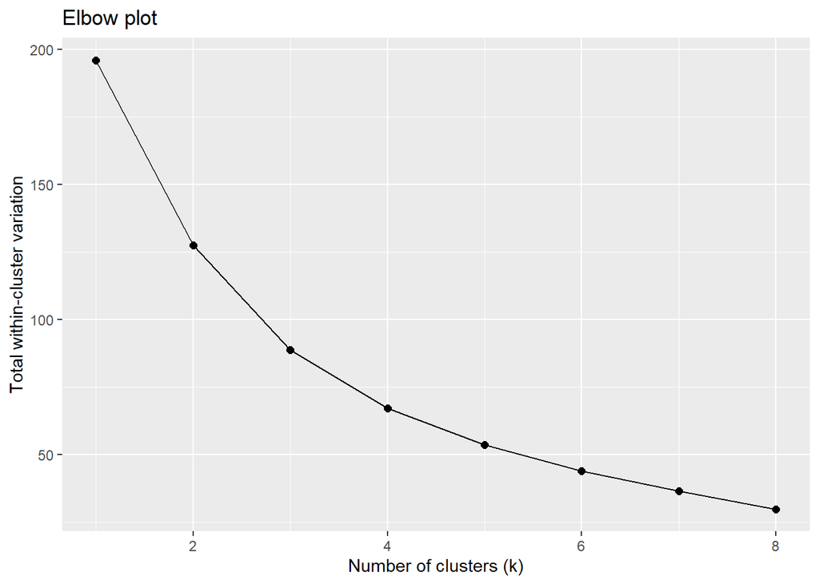

| cluster | hotels | avg_price | avg_rating | avg_value_rating | avg_rooms |
| --- | --- | --- | --- | --- | --- |
| Group 1 | 17 | 136 | 3.12 | 3.24 | 30 |
| Group 2 | 3 | 236 | 3.73 | 3.9 | 163 |
| Group 3 | 30 | 206 | 4.39 | 4.47 | 21 |

```
## Ramada belongs to: Group 1
```

| name | category | price | rating_overall | rating_value | room |
| --- | --- | --- | --- | --- | --- |
| Sails Motor Inn | Hotel | 293 | 2.7 | 2.9 | 13 |
| Ramada by Wyndham Hamilton City Center | Hotel | 184 | 3 | 3.3 | 69 |
| Brooklyn Motor Lodge | Bed and Breakfast | 148 | 3.4 | 3.5 | 23 |
| Aaron Court Motor Inn | Bed and Breakfast | 147 | 3.4 | 3.9 | 39 |
| Cedar Lodge Motel | Hotel | 146 | 2.6 | 2.9 | 11 |
| Zeta Motel | Bed and Breakfast | 140 | 3.8 | 1 | 16 |
| Aspen Manor Motel | Hotel | 138 | 3.3 | 3.2 | 31 |
| Barclay Motel | Hotel | 133 | 3.8 | 3.9 | 21 |
| Tudor Motor Lodge | Hotel | 130 | 3.3 | 3.6 | 24 |
| Uni Motel | Hotel | 129 | 3 | 3.2 | 11 |
| Lake Point Motel | Hotel | 126 | 3.5 | 4 | 20 |
| Grosvenor Motor Inn | Hotel | 118 | 2.2 | 2.8 | 40 |
| Anglesea Motel & Conference Centre | Hotel | 116 | 3.5 | 3.7 | 48 |
| Colonial City Motel | Hotel | 110 | 3.4 | 4.1 | 17 |
| Alcamo Hotel - Hamilton | Hotel | 100 | 2 | 2.3 | 56 |
| Microtel Lodge Hamilton | Specialty Lodging | 79.5 | 3.2 | 3.4 | 17 |
| Backpackers Central Hamilton | Specialty Lodging | 74 | 3 | 3.4 | 48 |

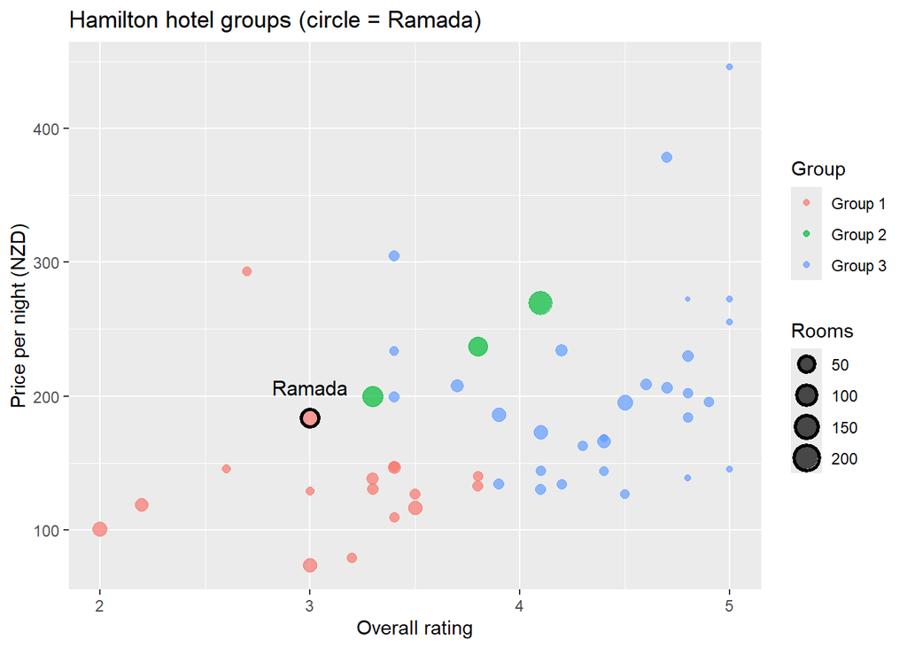

**Interpretation:**

- The elbow plot declines smoothly without a sharp bend, so the choice is partly a judgement. Three groups give a clear and useful story, but the result should be seen as a description, not a precise rule. Only 50 Hamilton hotels have complete data.
- Group 1 (17 hotels): average price $136, rating 3.12, value rating 3.24, about 30 rooms. Mostly motels and lodges with average guest satisfaction.
- Group 2 (3 hotels): large properties (about 163 rooms), price $236, rating 3.73.
- Group 3 (30 hotels): price $206, rating 4.39, value rating 4.47, small (about 21 rooms). These are the best-rated hotels.
- Ramada belongs to Group 1, so its real peers are lower-rated motels and lodges, not the top-rated hotels. Within this group, Ramada’s price of $183.50 is the second highest (only Sails Motor Inn at $293 is higher) and about $48 (35%) above the group average of $136, while its rating (3.0) and value rating (3.3) are about the same as the group’s (3.12 and 3.24).
- By contrast, guests of the high-rated Group 3 pay only about $22 (11%) more than Ramada’s price but rate their hotels 4.39.
- Ramada charges almost the price of the top group for the satisfaction level of its peer group. This explains its weak value-for-money score and is another reason not to raise the price.